# Not all subsidies are equal: Measuring preferences for electric vehicle financial incentives

*Roberson, Laura A. & **Helveston, John P.**  
*Environmental Research Letters*, 2022  
DOI: 10.1088/1748-9326/ac7df3

[View](https://iopscience.iop.org/article/10.1088/1748-9326/ac7df3) [PDF](https://iopscience.iop.org/article/10.1088/1748-9326/ac7df3/pdf) [Code & Data](https://zenodo.org/record/6807674)

### Haiku Summary

*EV subsidies ~ should be instant cash rebates ~ and not tax credits*

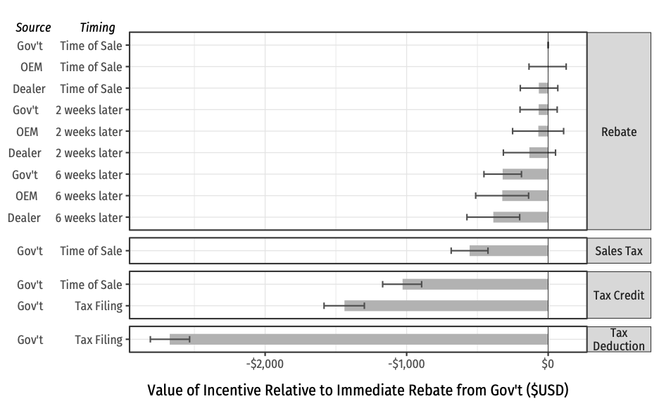

**Abstract**:

Financial incentives, such as purchase subsidies, have been found to increase plug-in electric vehicle (PEV) adoption, but how these incentives are designed can impact their effectiveness as well as how equitably they are distributed. Using a national conjoint survey (N = 2,170 respondents), we quantify how U.S. vehicle buyers value different features of PEV financial incentives. Participants overwhelmingly prefer immediate rebates, on average valuing them by $580, $1,450, and $2,630 more than sales tax exemptions, tax credits, or tax deductions, respectively. These effects are significantly larger for lower-income households, used vehicle buyers, and buyers with lower budgets. We estimate that on average $2 billion could have been saved if the federal subsidy available between 2011 and 2019 were delivered as an immediate rebate instead of a tax credit, or $1,440 per PEV sold. Our results suggest that structuring incentives as immediate rebates would deliver a greater value to customers and would be more equitably distributed compared to the current tax credit scheme.

**Recommended Citation**:

Roberson, Laura A. & **Helveston, John P.** (2022) “Not all subsidies are equal: Measuring preferences for electric vehicle financial incentives” *Environmental Research Letters*. 17(084003). DOI: 10.1088/1748-9326/ac7df3

**Bibtex**:

```
@article{roberson2022erl,
    author={Roberson, Laura A. and Helveston, John Paul},
    title={Not all subsidies are equal: Measuring preferences for electric vehicle financial incentives},
    journal={Environmental Research Letters},
    year={2022},
    volume={17},
    number={8},
    pages={084003},
    doi = {10.1088/1748-9326/ac7df3}
}
```

Share: